# Projekt 3-4

Anna Wójcik, Dawid Dąbkowski, Grzegorz Ziajka

19 kwietnia 2017

# 1 Podsumowanie

W częściach 3,4 zbadamy wpływ zmiennych dotyczących ucznia: jego płci, kraju pochodzenia oraz wersji rozwiązywanego przez niego testu na czas rozwiązania poszczególnych zadań. Wykonamy kolejno analizy jednokierunkowe dla wyżej wymienionych zmiennych, po których nastąpią analizy wielokierunkowe. W kolejnych krokach do modelu dodamy zmienne poprzednio zidentyfikowane jako istotne oraz spróbujemy dokonać selekcji zmiennych z użyciem metody regresji krokowej w oparciu o kryteria AIC i BIC. Finalny model(o najniższym AIC oraz BIC) poddamy diagnostyce oraz dokonamy wizualizacji jego parametrów.

# 2 Przygotowanie danych

```r
library("ggplot2")
library("dplyr")
library("tidyr")
library("lmtest")
library("MASS")
```

Przygotujemy dane do analizy. Usuniemy wszystkie rekordy, w których interesujące nas zmienne są NA (lub -1) oraz wylosujmy próbkę wielkości jednego miliona do bardziej skomplikowanych analiz.

```r
load("actionTimeScoreGender.rda") # dane o zadaniach z matematyki plus plec

actionTimeScoreGender <- separate(actionTimeScoreGender, item_short, into = c('M', 'Q'), sep = 4)

actionTimeScoreGender$M <- as.factor(actionTimeScoreGender$M)
actionTimeScoreGender$Q <- as.factor(actionTimeScoreGender$Q)
actionTimeScoreGender$position <- replace(actionTimeScoreGender$position, actionTimeScoreGender$position==-1, NA)
actionTimeScoreGender$position <- droplevels(actionTimeScoreGender$position)

indeksy <- quantile(actionTimeScoreGender$T, probs=c(0.01, 0.99))
actionTimeScoreGender <- filter(actionTimeScoreGender, T <= indeksy[2])
actionTimeScoreGender <- filter(actionTimeScoreGender, T >= indeksy[1])

actionTimeScoreGender <- actionTimeScoreGender[complete.cases(actionTimeScoreGender),]

actionTimeScoreGenderSample <- sample_n(actionTimeScoreGender, 1000000)
```

# 3 Analiza jednokierunkowa

Przejdźmy do analizy wpływu cech ucznia (płeć, kraj, kwestionariusz) na czas rozwiązywania zadania.

## 3.1 Wpływ płci

Zacznijmy od zbadaniu wpływu płci:

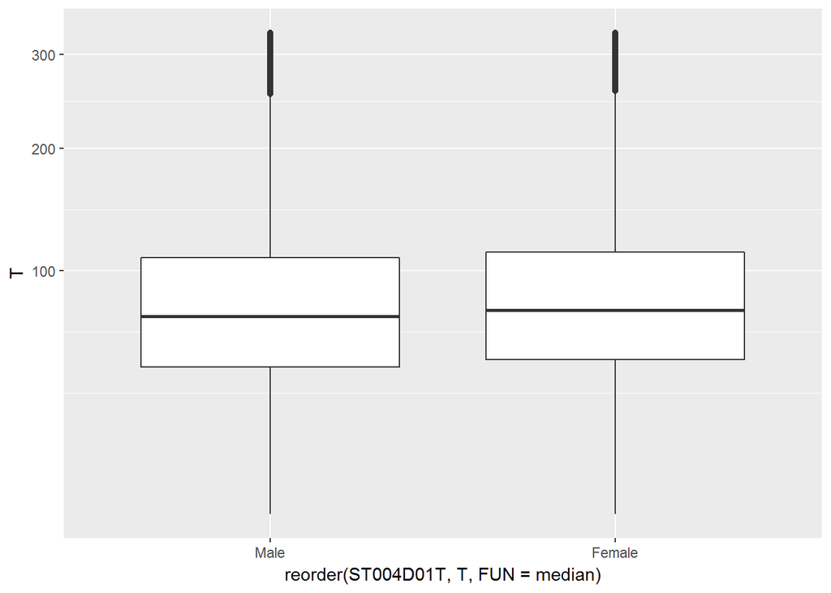

```r
ggplot(actionTimeScoreGender, aes(x = reorder(ST004D01T, T, FUN = median), y = T)) + geom_boxplot() + scale_y_sqrt()
```

```r
anova(lm(sqrt(T) ~ ST004D01T, data = actionTimeScoreGender))
```

```
## Analysis of Variance Table
##
## Response: sqrt(T)
##                Df   Sum Sq Mean Sq F value    Pr(>F)
## ST004D01T       1    36299   36299  4296.1 < 2.2e-16 ***
## Residuals 2661960 22492070       8
## ---
## Signif. codes:  0 '***' 0.001 '**' 0.01 '*' 0.05 '.' 0.1 ' ' 1
```

Wyniki analizy wariancji wskazują że średnie czasy rozwiązywania zadań różnią się w zależności od płci.

## 3.2 Wpływ kraju pochodzenia ucznia

Przejdźmy do analizy zależności między czasem wykonania zadania a krajem pochodzenia ucznia:

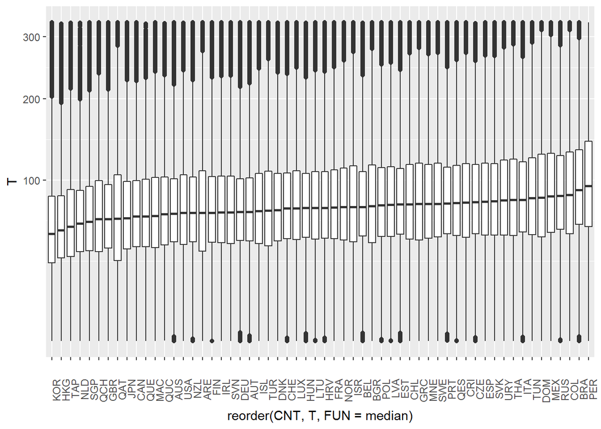

```r
ggplot(actionTimeScoreGender, aes(x = reorder(CNT, T, FUN = median), y = T)) + geom_boxplot() + scale_y_sqrt() + theme(axis.text.x = element_text(angle = 90, hjust = 1))
```

```r
anova(lm(sqrt(T) ~ CNT, data = actionTimeScoreGender))
```

```
## Analysis of Variance Table
##
## Response: sqrt(T)
##                Df   Sum Sq Mean Sq F value    Pr(>F)
## CNT            57   581854 10208.0  1238.1 < 2.2e-16 ***
## Residuals 2661904 21946515     8.2
## ---
## Signif. codes:  0 '***' 0.001 '**' 0.01 '*' 0.05 '.' 0.1 ' ' 1
```

Ponownie, widzimy że przeciętny czas wykonania zadania zależy od kraju pochodzenia ucznia.

## 3.3 Wpływ wersji kwestionariusza

Na koniec zbadajmy zależność między czasem wykonania zadania a wersją kwestionariusza rozwiązywaną przez ucznia:

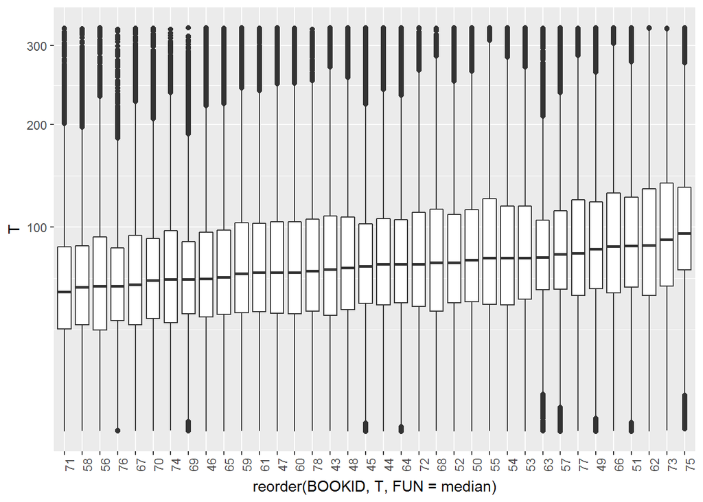

```r
ggplot(actionTimeScoreGender, aes(x = reorder(BOOKID, T, FUN = median), y = T)) + geom_boxplot() + scale_y_sqrt() + theme(axis.text.x = element_text(angle = 90, hjust = 1))
```

```r
anova(lm(sqrt(T) ~ BOOKID, data = actionTimeScoreGender))
```

```
## Analysis of Variance Table
##
## Response: sqrt(T)
##                Df   Sum Sq Mean Sq F value    Pr(>F)
## BOOKID         35   439014 12543.2  1511.6 < 2.2e-16 ***
## Residuals 2661926 22089355     8.3
## ---
## Signif. codes:  0 '***' 0.001 '**' 0.01 '*' 0.05 '.' 0.1 ' ' 1
```

Tak jak poprzednio widzimy że czas wykonania zadania zależy od wersji kwestionariusza.

# 4 Analiza wielokierunkowa

## 4.1 Kraj pochodzenia ucznia + płeć ucznia

```r
anova(lm(sqrt(T) ~ ST004D01T + CNT, data = actionTimeScoreGender))
```

```
## Analysis of Variance Table
##
## Response: sqrt(T)
##                Df   Sum Sq Mean Sq F value    Pr(>F)
## ST004D01T       1    36299   36299  4409.4 < 2.2e-16 ***
## CNT            57   578754   10154  1233.4 < 2.2e-16 ***
## Residuals 2661903 21913316       8
## ---
## Signif. codes:  0 '***' 0.001 '**' 0.01 '*' 0.05 '.' 0.1 ' ' 1
```

```r
anova(lm(sqrt(T) ~ CNT + ST004D01T, data = actionTimeScoreGender))
```

```
## Analysis of Variance Table
##
## Response: sqrt(T)
##                Df   Sum Sq Mean Sq F value    Pr(>F)
## CNT            57   581854   10208  1240.0 < 2.2e-16 ***
## ST004D01T       1    33199   33199  4032.8 < 2.2e-16 ***
## Residuals 2661903 21913316       8
## ---
## Signif. codes:  0 '***' 0.001 '**' 0.01 '*' 0.05 '.' 0.1 ' ' 1
```

Wyniki analizy dwukierunkowej mówią że niezależnie od kolejności zmienne płeć oraz kraj pochodzenia ucznia zachowują istotność.

## 4.2 Płeć ucznia + wersja testu

```r
anova(lm(sqrt(T) ~ ST004D01T + BOOKID, data = actionTimeScoreGender))
```

```
## Analysis of Variance Table
##
## Response: sqrt(T)
##                Df   Sum Sq Mean Sq F value    Pr(>F)
## ST004D01T       1    36299   36299  4381.6 < 2.2e-16 ***
## BOOKID         35   439414   12555  1515.4 < 2.2e-16 ***
## Residuals 2661925 22052656       8
## ---
## Signif. codes:  0 '***' 0.001 '**' 0.01 '*' 0.05 '.' 0.1 ' ' 1
```

```r
anova(lm(sqrt(T) ~ BOOKID + ST004D01T, data = actionTimeScoreGender))
```

```
## Analysis of Variance Table
##
## Response: sqrt(T)
##                Df   Sum Sq Mean Sq F value    Pr(>F)
## BOOKID         35   439014   12543  1514.1 < 2.2e-16 ***
## ST004D01T       1    36700   36700  4429.9 < 2.2e-16 ***
## Residuals 2661925 22052656       8
## ---
## Signif. codes:  0 '***' 0.001 '**' 0.01 '*' 0.05 '.' 0.1 ' ' 1
```

Wyniki analizy dwukierunkowej mówią że niezależnie od kolejności zmienne płeć oraz wersja testu zachowują istotność.

## 4.3 Kraj pochodzenia + wersja testu

```r
anova(lm(sqrt(T) ~ CNT + BOOKID, data = actionTimeScoreGender))
```

```
## Analysis of Variance Table
##
## Response: sqrt(T)
##                Df   Sum Sq Mean Sq F value    Pr(>F)
## CNT            57   581854 10208.0  1263.6 < 2.2e-16 ***
## BOOKID         35   441812 12623.2  1562.5 < 2.2e-16 ***
## Residuals 2661869 21504703     8.1
## ---
## Signif. codes:  0 '***' 0.001 '**' 0.01 '*' 0.05 '.' 0.1 ' ' 1
```

```r
anova(lm(sqrt(T) ~ BOOKID + CNT, data = actionTimeScoreGender))
```

```
## Analysis of Variance Table
##
## Response: sqrt(T)
##                Df   Sum Sq Mean Sq F value    Pr(>F)
## BOOKID         35   439014 12543.2  1552.6 < 2.2e-16 ***
## CNT            57   584652 10257.1  1269.6 < 2.2e-16 ***
## Residuals 2661869 21504703     8.1
## ---
## Signif. codes:  0 '***' 0.001 '**' 0.01 '*' 0.05 '.' 0.1 ' ' 1
```

Wyniki analizy dwukierunkowej mówią że niezależnie od kolejności zmienne kraj pochodzenia ucznia oraz wersja testu zachowują istotność.

## 4.4 Cechy ucznia razem

```r
anova(lm(sqrt(T) ~ CNT + ST004D01T + BOOKID, data = actionTimeScoreGender))
```

```
## Analysis of Variance Table
##
## Response: sqrt(T)
##                Df   Sum Sq Mean Sq F value    Pr(>F)
## CNT            57   581854   10208  1265.5 < 2.2e-16 ***
## ST004D01T       1    33199   33199  4115.8 < 2.2e-16 ***
## BOOKID         35   442177   12634  1566.2 < 2.2e-16 ***
## Residuals 2661868 21471139       8
## ---
## Signif. codes:  0 '***' 0.001 '**' 0.01 '*' 0.05 '.' 0.1 ' ' 1
```

```r
anova(lm(sqrt(T) ~ BOOKID + ST004D01T + CNT, data = actionTimeScoreGender))
```

```
## Analysis of Variance Table
##
## Response: sqrt(T)
##                Df   Sum Sq Mean Sq F value    Pr(>F)
## BOOKID         35   439014   12543  1555.0 < 2.2e-16 ***
## ST004D01T       1    36700   36700  4549.8 < 2.2e-16 ***
## CNT            57   581517   10202  1264.8 < 2.2e-16 ***
## Residuals 2661868 21471139       8
## ---
## Signif. codes:  0 '***' 0.001 '**' 0.01 '*' 0.05 '.' 0.1 ' ' 1
```

# 5 Model zbudowany na cechach zadania i ucznia

Dodajmy zmienne poprzednio zidentyfikowane jako istotne czyli pozycja zadania w teście oraz numer zadania, zachowamy poprzednio znalezione przekształcenie zmiennej zależnej za pomocą pierwiastka kwadratowego.

```r
m1 <- lm(sqrt(T) ~ CNT + ST004D01T + BOOKID + position + M/Q, data = actionTimeScoreGenderSample)
```

Dla powyższego modelu wykonamy jeszcze analizę wariancji oraz spróbujemy usunąć zbędne zmienne za pomocą regresji krokowej “w tył” z użyciem kryteriów AIC i BIC.

```r
anova(m1)
```

```
## Analysis of Variance Table
##
## Response: sqrt(T)
##               Df  Sum Sq Mean Sq F value    Pr(>F)
## CNT           57  220696  3871.9  586.57 < 2.2e-16 ***
## ST004D01T      1   12260 12260.2 1857.37 < 2.2e-16 ***
## BOOKID        35  168079  4802.3  727.52 < 2.2e-16 ***
## position       2   54802 27401.2 4151.16 < 2.2e-16 ***
## M             40 1134128 28353.2 4295.39 < 2.2e-16 ***
## M:Q           19  268752 14144.9 2142.89 < 2.2e-16 ***
## Residuals 999845 6599818     6.6
## ---
## Signif. codes:  0 '***' 0.001 '**' 0.01 '*' 0.05 '.' 0.1 ' ' 1
```

```r
m2 <- step(m1)
```

```
## Start:  AIC=1887352
## sqrt(T) ~ CNT + ST004D01T + BOOKID + position + M/Q
##
##             Df Sum of Sq     RSS     AIC
## <none>                   6599818 1887352
## - ST004D01T  1     12357 6612175 1889221
## - BOOKID    34     21321 6621139 1890509
## - position   2     52826 6652645 1895320
## - CNT       57    261205 6861024 1926053
## - M:Q       19    268752 6868571 1927228
```

```r
m3 <- step(m1, k = log(nrow(actionTimeScoreGenderSample)))
```

```
## Start:  AIC=1889184
## sqrt(T) ~ CNT + ST004D01T + BOOKID + position + M/Q
##
##             Df Sum of Sq     RSS     AIC
## <none>                   6599818 1889184
## - ST004D01T  1     12357 6612175 1891040
## - BOOKID    34     21321 6621139 1891939
## - position   2     52826 6652645 1897128
## - CNT       57    261205 6861024 1927211
## - M:Q       19    268752 6868571 1928835
```

Wyniki analizy wariancji oraz regresji krokowej są spójne - wszystkie użyte w modelu zmienne są istotne, dodatkowo usunięcie którejkolwiek z niej pogarsza jakość modelu według kryteriów AIC i BIC.

## 5.1 Diagnostyka

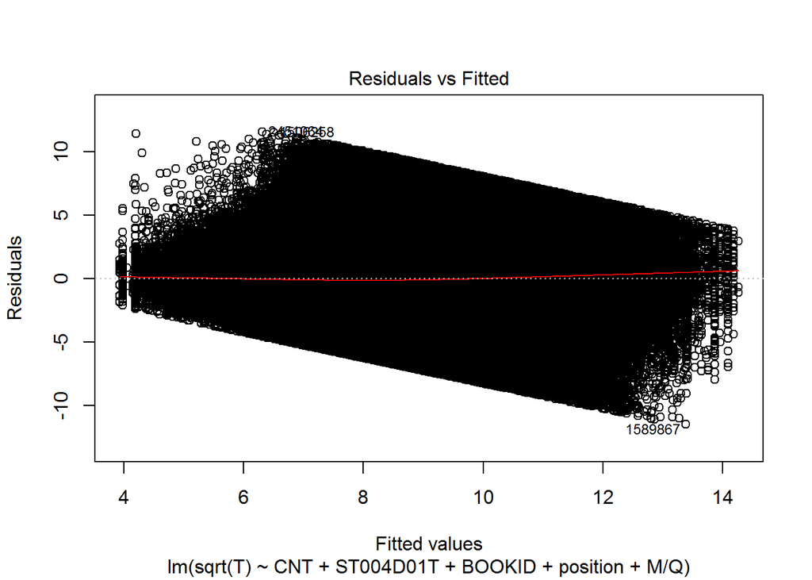

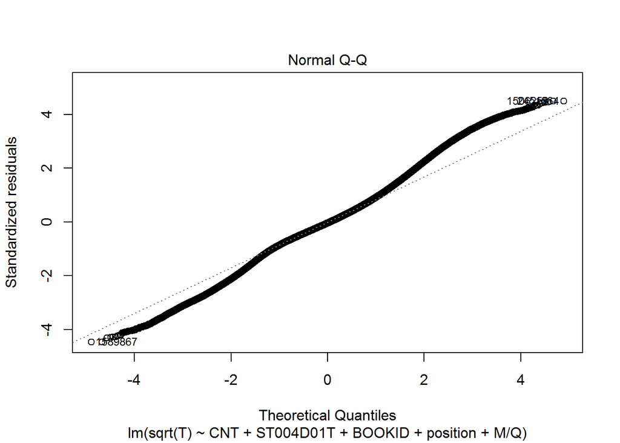

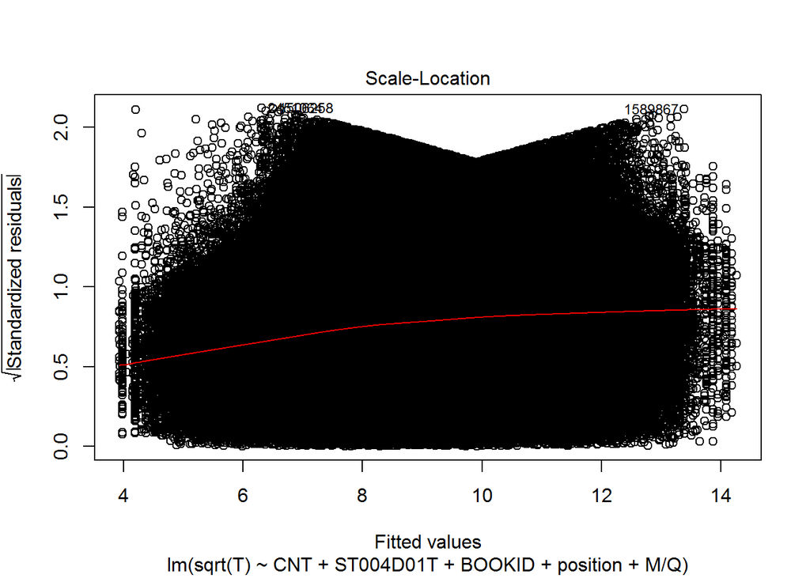

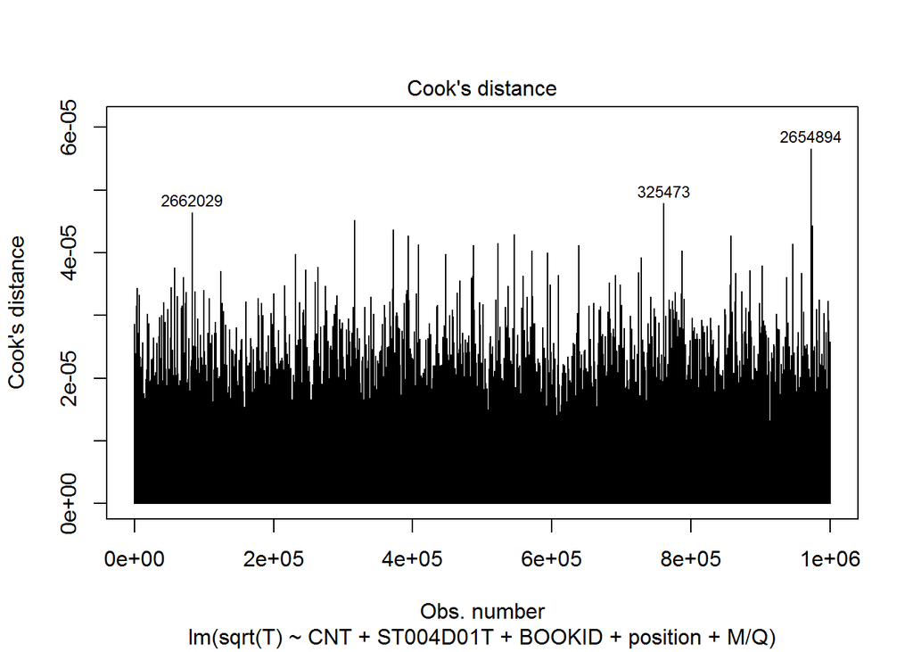

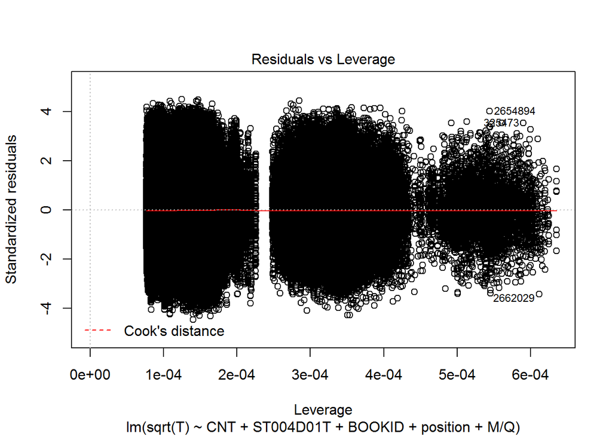

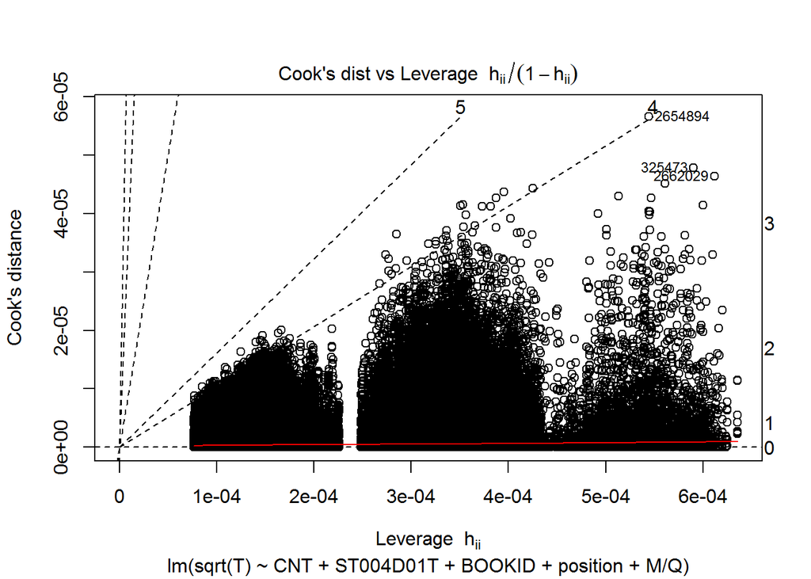

Wykres 1 - istnieją niewielkie problemy z jednorodnością wariancji - werdykt negatywny co potwierdza późniejszy test Breuscha-Pagana.  
Wykres 2 - reszty modelu nie mają rozkładu normalnego, widoczne są grubsze ogony - werdykt neutralny.  
Wykres 3 - widoczna jest zależność reszt od wartości dopasowanych - werdykt negatywny.  
Wykres 4,5,6 - miary Cook’a obserwacji są niewielkie - wszystko w porządku.

Wykonamy jeszcze test jednorodności wariancji Breuscha-Pagana

```r
bptest(m1)
```

```
##
##  studentized Breusch-Pagan test
##
## data:  m1
## BP = 53316, df = 154, p-value < 2.2e-16
```

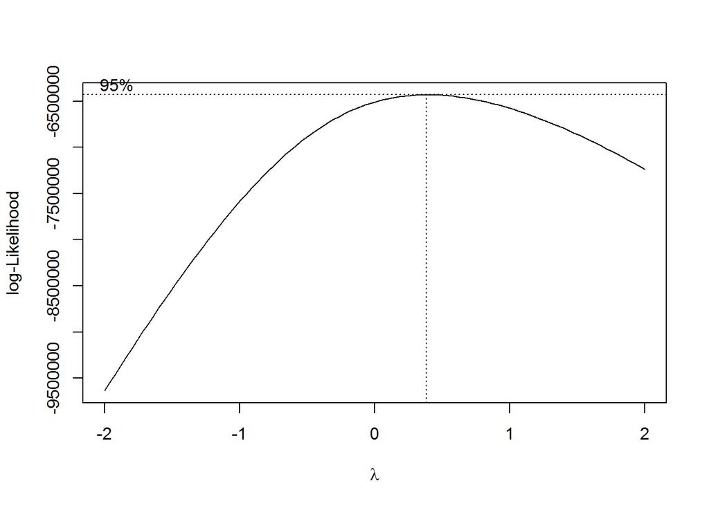

```r
mBC = boxcox(T ~ CNT + ST004D01T + BOOKID + position + M/Q, data = actionTimeScoreGenderSample)
```

```r
lambda = mBC$x[which.max(mBC$y)]

lambda
```

```
## [1] 0.3838384
```

```r
m4 = lm((T^lambda-1)/lambda ~ CNT + ST004D01T + BOOKID + position + M/Q, data = actionTimeScoreGenderSample)
```

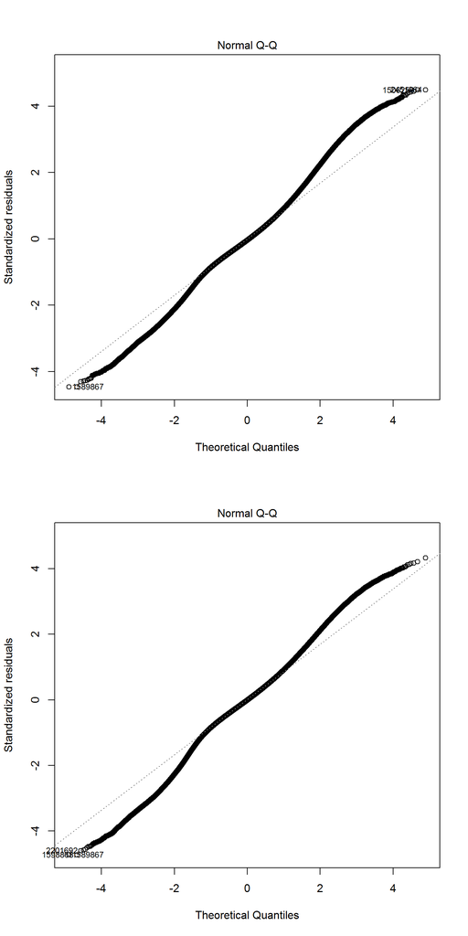

Powyżej porównanie modelu bazowego (na górze) oraz modelu z sugerowaną transformacją Boxa-Coxa, rozkłady reszt nie różnią się znacząco dlatego pozostaniemy przy modelu podstawowym.

## 5.2 Wizualizacja współczynników modelu

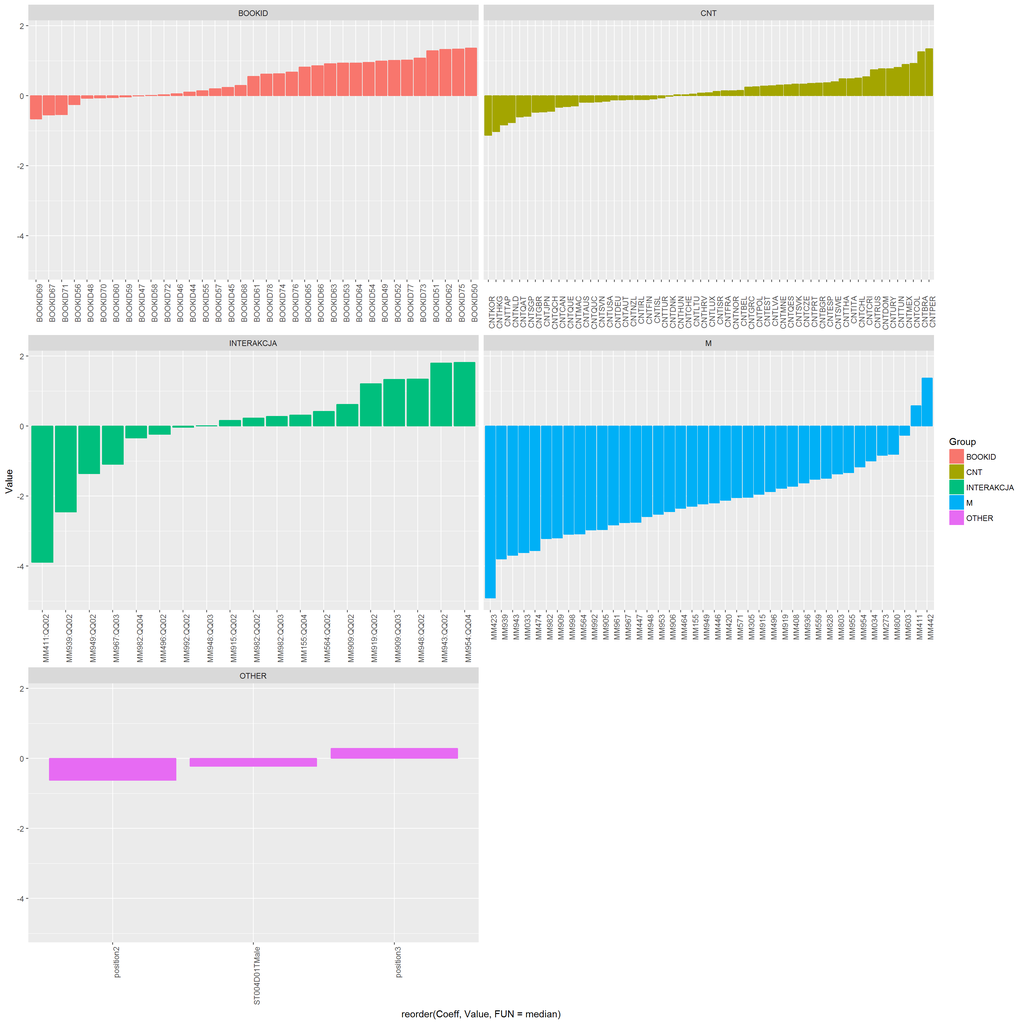